# Classificazione di Immagini MRI Tumorali tramite l’uso di Reti Neurali Convoluzionali (CNN)

Alessandro Poli matr.n. 869597

2026-01-27

### 1.Introduzione

Questo progetto di *Deep Learning* affronta lo svolgimento e la risoluzione di un problema di classificazione multiclasse di immagini celebrali ottenute con MRI.

L’obiettivo del progetto è duplice:

- 1. Confrontare le performance di Reti Convoluzionali che differiscono tra loro, sia per architettura ( *numero di layer e numero di nodi*), sia a seguito dell’utilizzo di strumenti ’*ad hoc* , come il *dropoff* per la mitigazione dell’overfitting e/o l’uso della *data augmentation* per aumentare la *‘varietà’* campionaria.
- 2. Porre efasi sull’interpretazione dei risultati, in particolar modo sugli errori di classificazione, estremamente delicati e importanti nel contesto clinico-medico.

Verrano seguiti i seguenti step:

- Importazione del dataset e split in Training/ Validation/ Test
- Costruzione di una *CNN baseline*
- Costruzione di moltiplici CNN con architettura e/o con l’uso tecniche aggiuntive
- Scelta del miglior modello
- Previsioni sul Test Set
- Conclusioni

### 2. Descrizione e Importazione del dataset

Il dataset è scaricabile dal seguente link Kaggle: https://www.kaggle.com/datasets/miadul/brain-tumor-mri-dataset. Esso raccoglie un totale di *7023 scansioni MRI*, ognuna già associata ad una label appartenente a una delle quattro classi: {Healthy, Menignoma, Glioma, Pituitary }. La classe *Healthy* rappresenta l’assenza di tumori celebrali, mentre le le restanti tre rappresentano tre diverse tipologie di tumori nominati.

Dal punto di vista più operativo, il dataset scaricato si presenta in un unica cartella, denominata *‘brain_tumor_dataset’*. All’interno di questa cartella si trovamo quattro sottocartelle, una per ciascuna classe del problema di classificazione, contenenti le immagini MRI relative ai loro rispettivi casi.

Questa organizzazione gerarchica delle cartelle permette di accelerare il lavoro, facilitando l’importazione delle immagini in memoria, permette di poter rapidamente passare passare alla suddivisione del dataset in training, validation e test set.

```r
# Imposto seed per la riproducibilità #
set.seed(123)
# Creo le cartelle necessarie e organizzo il lavoro ##
getwd()
```

```
## [1] "C:/Users/AP869597/Desktop"
```

```r
unzip('C:/Users/AP869597/Desktop/archive.zip',exdir='C:/Users/AP869597/Desktop/progetto_learning')

# Definisco le directory del training, validation e del test

base_dir<-'C:/Users/AP869597/Desktop/progetto_learning'
train_dir<-file.path(base_dir,'train')
test_dir<-file.path(base_dir,'test')
val_dir<-file.path(base_dir,'validation')

# creo le cartelle vuote mantenendo i nomi delle diverse classi

dirs<-c(
  file.path(train_dir,'glioma'),
  file.path(train_dir,'healthy'),
  file.path(train_dir,'meningioma'),
  file.path(train_dir,'pituitary'),

  file.path(test_dir,'glioma'),
  file.path(test_dir,'healthy'),
  file.path(test_dir,'meningioma'),
  file.path(test_dir,'pituitary'),

  file.path(val_dir,'glioma'),
  file.path(val_dir,'healthy'),
  file.path(val_dir,'meningioma'),
  file.path(val_dir,'pituitary')

)
invisible(lapply(dirs,dir.create,showWarnings=F,recursive=T))

# Ora devo riempire ogni cartella con le immagini concorde alla loro label
# definisco le directory della cartelle dalle quali prelevare le immagini

original_dataset_dir_glioma<- 'C:/Users/AP869597/Desktop/progetto_learning/brain_tumor_dataset/glioma'
original_dataset_dir_healthy<- 'C:/Users/AP869597/Desktop/progetto_learning/brain_tumor_dataset/healthy'
original_dataset_dir_meningioma<- 'C:/Users/AP869597/Desktop/progetto_learning/brain_tumor_dataset/meningioma'
original_dataset_dir_pituitary<- 'C:/Users/AP869597/Desktop/progetto_learning/brain_tumor_dataset/pituitary'
```

Dalle analisi delle cartelle fisiche risulta che le classi sono complessivamente ben bilanciate:

- Glioma = 1621 obs.
- Healthy = 2000 obs.
- Meningioma = 1645 obs.
- Pituitary = 1757 obs.

Per delle analisi accurate si è comunque scelto di ottenere i fold di training, validation e set stratificando per classe. E’ stata adottata una partizione 70/15/15, garantendo che le osservazioni siano mutualmente esclusive a ciascun fold a loro associato. La procedura svolta è la seguente:

- 85% delle obs. di ogni classe costituisce il training set.
- di queste il 15% di ogni classe forma il validation set.
- il 15% delle obs. rimanenti di ogni classe il test set.

```r
# leggo tutte le immagini di tutte le K classi

# Glioma
fnames_glioma <- list.files(
  original_dataset_dir_glioma,
  pattern = "\\.jpg$",
  full.names = TRUE
)
# Healthy
fnames_healthy <- list.files(
  original_dataset_dir_healthy,
  pattern = "\\.jpg$",
  full.names = TRUE
)
# Meningioma
fnames_meningioma<- list.files(
  original_dataset_dir_meningioma,
  pattern = "\\.jpg$",
  full.names = TRUE
)
# Pituitary
fnames_pituitary <- list.files(
  original_dataset_dir_pituitary,
  pattern = "\\.jpg$",
  full.names = TRUE
)

# Dichiaro una funzione per la creazione del training, validation e del test set.

data_separation <- function(data, seed=123) {
  set.seed(seed)
  n <- length(data)
  ind <- sample(1:n, size = floor(0.85 * n))
  train_val <- data[ind]
  test      <- data[-ind]
  rapp <- 0.7 / 0.85   # proporzione 15% su train_val
  m <- length(train_val)
  k <- sample(1:m, size = floor(rapp * m))
  train <- train_val[k]
  val   <- train_val[-k]
  return(list(train = train, val = val, test = test))
}

splits_glioma <- data_separation(fnames_glioma)
splits_healthy <- data_separation(fnames_healthy)
splits_meningioma <- data_separation(fnames_meningioma)
splits_pituitary  <- data_separation(fnames_pituitary)

# Formo per ogni classe Training/Validation/Test:

# Glioma

glioma_train<-splits_glioma$train
glioma_test<-splits_glioma$test
glioma_val<-splits_glioma$val

# Healthy
healthy_train<-splits_healthy$train
healthy_test<-splits_healthy$test
healthy_val<-splits_healthy$val

# Meningioma
meningioma_train<-splits_meningioma$train
meningioma_test<-splits_meningioma$test
meningioma_val<-splits_meningioma$val

# Pituitary
pituitary_train<-splits_pituitary$train
pituitary_test<-splits_pituitary$test
pituitary_val<-splits_pituitary$val


# check dimensioni
round(length(splits_glioma$train) / length(fnames_glioma),3)  # ~0.7
```

```
## [1] 0.7
```

```r
round(length(splits_glioma$val) / length(fnames_glioma),3)  # ~0.15
```

```
## [1] 0.15
```

```r
round(length(splits_glioma$test) / length(fnames_glioma),3)   # ~0.15
```

```
## [1] 0.151
```

```r
# riempio le cartelle di GLIOMA corrispondenti

invisible(file.copy(
  from = glioma_train,
  to   = "C:/Users/AP869597/Desktop/progetto_learning/train/glioma"
))

invisible(
file.copy(
  from = glioma_val,
  to   = "C:/Users/AP869597/Desktop/progetto_learning/validation/glioma"
))

invisible(
file.copy(
  from = glioma_test,
  to   = "C:/Users/AP869597/Desktop/progetto_learning/test/glioma"
))

# Check #
round(length(glioma_train)/length(fnames_glioma),3)
```

```
## [1] 0.7
```

```r
round(length(glioma_val)/length(fnames_glioma),3)
```

```
## [1] 0.15
```

```r
round(length(glioma_test)/length(fnames_glioma),3)
```

```
## [1] 0.151
```

```r
# Ora faccio esattamente la stessa cosa con tutte le altre classi

#############  HEALTHY ###############
invisible(file.copy(
  from = healthy_train,
  to   = "C:/Users/AP869597/Desktop/progetto_learning/train/healthy"
))

invisible(
file.copy(
  from = healthy_val,
  to   = "C:/Users/AP869597/Desktop/progetto_learning/validation/healthy"
))


invisible(
file.copy(
  from = healthy_test,
  to   = "C:/Users/AP869597/Desktop/progetto_learning/test/healthy"
))

################ MENINGIOMA ###############

invisible(
file.copy(
  from = meningioma_train,
  to   = "C:/Users/AP869597/Desktop/progetto_learning/train/meningioma"
))

invisible(
file.copy(
  from = meningioma_val,
  to   = "C:/Users/AP869597/Desktop/progetto_learning/validation/meningioma"
))


invisible(
file.copy(
  from = meningioma_test,
  to   = "C:/Users/AP869597/Desktop/progetto_learning/test/meningioma"
))

############## PITUITARY ######################
invisible(
file.copy(
  from = pituitary_train,
  to   = "C:/Users/AP869597/Desktop/progetto_learning/train/pituitary"
))

invisible(
file.copy(
  from = pituitary_val,
  to   = "C:/Users/AP869597/Desktop/progetto_learning/validation/pituitary"
))


invisible(
file.copy(
  from = pituitary_test,
  to   = "C:/Users/AP869597/Desktop/progetto_learning/test/pituitary"
))
```

Dopo aver suddiviso i dati in training, validation e test per ciascuna delle quattro classi, i sottoinsiemi vengono uniti per ottenere un unico training set, un unico validation set e un unico test set, preservando la proporzione delle classi del dataset originale. Si ottengo le diverse numerodità:

- *Training* = 4914 obs.
- *Validation* = 1054 obs.
- *Test* = 1055 obs.

```r
# creo i vettori di file/label

train_images<-c(glioma_train,healthy_train,meningioma_train,pituitary_train)
train_labels <- c(
  rep("glioma", length(glioma_train)),
  rep("healthy", length(healthy_train)),
  rep("meningioma", length(meningioma_train)),
  rep("pituitary", length(pituitary_train))
)


val_files <- c(glioma_val, healthy_val, meningioma_val, pituitary_val)
val_labels <- c(
  rep("glioma", length(glioma_val)),
  rep("healthy", length(healthy_val)),
  rep("meningioma", length(meningioma_val)),
  rep("pituitary", length(pituitary_val))
)


test_files <- c(glioma_test, healthy_test, meningioma_test, pituitary_test)
test_labels <- c(
  rep("glioma", length(glioma_test)),
  rep("healthy", length(healthy_test)),
  rep("meningioma", length(meningioma_test)),
  rep("pituitary", length(pituitary_test))
)

# carico le immagini nella cartella train

train_ds <- image_dataset_from_directory(
  "C:/Users/AP869597/Desktop/progetto_learning/train",
  image_size = c(150,150),
  batch_size = 32,
  color_mode = "grayscale",
  label_mode = "categorical",
  shuffle=T
)
```

```
## Found 4914 files belonging to 4 classes.
```

```r
val_ds <- image_dataset_from_directory(
  "C:/Users/AP869597/Desktop/progetto_learning/validation",
  image_size = c(150,150),
  batch_size = 32,
  color_mode = "grayscale",
  label_mode = "categorical",
  shuffle = TRUE
)
```

```
## Found 1054 files belonging to 4 classes.
```

```r
test_ds <- image_dataset_from_directory(
  "C:/Users/AP869597/Desktop/progetto_learning/test",
  image_size = c(150,150),
  batch_size = 32,
  color_mode = "grayscale",
  label_mode = "categorical",
  shuffle = FALSE
)
```

```
## Found 1055 files belonging to 4 classes.
```

### 3. Modellizzazione

Il primo step della fase di modellizzazione consiste nella realizzazione di una Rete Convoluzionale (CNN) semplice, che verrà utilizzata come *modello baseline* utile per il confronto delle performance con i modelli successivi.

Un aspetto importante da sottolineare è che l’operazione di preprocessing, in particolare la normalizzazione dei pixel delle immagini nell’intervallo [0,1], non è stata omessa, ma è stata integrata direttamente all’interno della funzione di definizione per ciascun modello che verrà implementato da questo punto in avanti.

E’ inoltre importante sottolineare che le scansioni MRI saranno trattate come immagini in biancho e nero. Questa infomazione sarà utile per la dimensione del filtro da utilizzare nei modelli.

A seguito di questa viene attaccata una rete neurale feed-forward formata da:

- **Layer con 216 nodi**:
  - Funzione di attivazione: **ReLU**
- **Layer di output**:
  - Numero di nodi: **4** (per le 4 classi da classificare)
  - Funzione di attivazione: **Softmax** (adatta per la classificazione multiclasse)

Per la definizione del processo di addestramento si è scelto di utilizzare:

- **Ottimizzatore**: **Adam**
  - durante lo sviluppo del lavoro si è utilizzato anche **RMSprop**, ma l’uso di **Adam** ha ridotto i tempi computazionali.
- **Funzione di perdita (Loss Function)**: **Categorical Cross-Entropy**
  - Adatta per problemi di **classificazione multiclasse**.
- **Numero di epoche**: **30** epoche per l’addestramento di ogni modello.
- **Metrica di valutazione**: **Accuracy**
  - utilizzata per misurare l’accuratezza del modello durante l’addestramento.

```r
# CNN BASELINE
model<- keras_model_sequential() %>%
  layer_rescaling(1/255, input_shape = c(150,150,1)) %>%
  layer_conv_2d(filters=32,kernel_size=c(3,3),activation='relu')%>%
  layer_max_pooling_2d(pool_size=c(2,2))%>%
  layer_conv_2d(filters=64,kernel_size=c(3,3),activation='relu')%>%
  layer_max_pooling_2d(pool_size=c(2,2))%>%
  layer_conv_2d(filters=128,kernel_size=c(3,3),activation='relu')%>%
  layer_flatten()%>%
  layer_dense(units=216,activation='relu')%>%
  layer_dense(units=4,activation='softmax')

model%>% compile(
  optimizer=c('adam'), # da provare anche Adam
  loss=c('categorical_crossentropy'),
  metrics=c('accuracy')
)

history<-model%>% fit(
  train_ds,
  epochs = 30,
  validation_data=val_ds
)
```

```
## 154/154 - 57s - 367ms/step - accuracy: 0.7287 - loss: 0.6838 - val_accuracy: 0.8454 - val_loss: 0.4311
## 154/154 - 55s - 354ms/step - accuracy: 0.8787 - loss: 0.3215 - val_accuracy: 0.8643 - val_loss: 0.3409
## 154/154 - 54s - 353ms/step - accuracy: 0.9312 - loss: 0.1823 - val_accuracy: 0.8975 - val_loss: 0.2940
## 154/154 - 54s - 348ms/step - accuracy: 0.9650 - loss: 0.1071 - val_accuracy: 0.9070 - val_loss: 0.2938
## 154/154 - 53s - 341ms/step - accuracy: 0.9823 - loss: 0.0516 - val_accuracy: 0.9194 - val_loss: 0.3039
## 154/154 - 52s - 336ms/step - accuracy: 0.9849 - loss: 0.0458 - val_accuracy: 0.9222 - val_loss: 0.3443
## 154/154 - 52s - 338ms/step - accuracy: 0.9876 - loss: 0.0369 - val_accuracy: 0.9175 - val_loss: 0.3620
## 154/154 - 52s - 338ms/step - accuracy: 0.9923 - loss: 0.0281 - val_accuracy: 0.9165 - val_loss: 0.3969
## 154/154 - 52s - 337ms/step - accuracy: 0.9957 - loss: 0.0135 - val_accuracy: 0.9213 - val_loss: 0.3976
## 154/154 - 52s - 336ms/step - accuracy: 0.9980 - loss: 0.0064 - val_accuracy: 0.9250 - val_loss: 0.4458
## 154/154 - 52s - 340ms/step - accuracy: 0.9963 - loss: 0.0090 - val_accuracy: 0.9231 - val_loss: 0.4807
## 154/154 - 52s - 339ms/step - accuracy: 1.0000 - loss: 0.0017 - val_accuracy: 0.9307 - val_loss: 0.4823
## 154/154 - 53s - 342ms/step - accuracy: 1.0000 - loss: 5.0042e-04 - val_accuracy: 0.9336 - val_loss: 0.5259
## 154/154 - 52s - 339ms/step - accuracy: 1.0000 - loss: 6.8269e-05 - val_accuracy: 0.9336 - val_loss: 0.5330
## 154/154 - 52s - 338ms/step - accuracy: 1.0000 - loss: 4.4163e-05 - val_accuracy: 0.9336 - val_loss: 0.5429
## 154/154 - 52s - 340ms/step - accuracy: 1.0000 - loss: 3.5024e-05 - val_accuracy: 0.9317 - val_loss: 0.5512
## 154/154 - 53s - 343ms/step - accuracy: 1.0000 - loss: 2.8785e-05 - val_accuracy: 0.9326 - val_loss: 0.5597
## 154/154 - 53s - 341ms/step - accuracy: 1.0000 - loss: 2.4376e-05 - val_accuracy: 0.9326 - val_loss: 0.5662
## 154/154 - 53s - 342ms/step - accuracy: 1.0000 - loss: 2.0678e-05 - val_accuracy: 0.9326 - val_loss: 0.5726
## 154/154 - 53s - 342ms/step - accuracy: 1.0000 - loss: 1.8053e-05 - val_accuracy: 0.9326 - val_loss: 0.5792
## 154/154 - 53s - 342ms/step - accuracy: 1.0000 - loss: 1.5717e-05 - val_accuracy: 0.9345 - val_loss: 0.5848
## 154/154 - 55s - 355ms/step - accuracy: 1.0000 - loss: 1.3792e-05 - val_accuracy: 0.9345 - val_loss: 0.5907
## 154/154 - 55s - 357ms/step - accuracy: 1.0000 - loss: 1.2189e-05 - val_accuracy: 0.9345 - val_loss: 0.5966
## 154/154 - 54s - 354ms/step - accuracy: 1.0000 - loss: 1.0833e-05 - val_accuracy: 0.9336 - val_loss: 0.6021
## 154/154 - 54s - 351ms/step - accuracy: 1.0000 - loss: 9.6661e-06 - val_accuracy: 0.9345 - val_loss: 0.6075
## 154/154 - 55s - 356ms/step - accuracy: 1.0000 - loss: 8.6043e-06 - val_accuracy: 0.9336 - val_loss: 0.6137
## 154/154 - 55s - 355ms/step - accuracy: 1.0000 - loss: 7.7149e-06 - val_accuracy: 0.9326 - val_loss: 0.6194
## 154/154 - 54s - 353ms/step - accuracy: 1.0000 - loss: 6.9262e-06 - val_accuracy: 0.9326 - val_loss: 0.6249
## 154/154 - 55s - 354ms/step - accuracy: 1.0000 - loss: 6.2316e-06 - val_accuracy: 0.9336 - val_loss: 0.6298
## 154/154 - 54s - 354ms/step - accuracy: 1.0000 - loss: 5.5849e-06 - val_accuracy: 0.9336 - val_loss: 0.6349
```

```r
summary(model)
```

```
## Model: "sequential"
## +------------------------------------------------------------------------------
## ¦ Layer (type)                      ¦ Output Shape             ¦       Param #
## +-----------------------------------+--------------------------+---------------
## ¦ rescaling (Rescaling)             ¦ (None, 150, 150, 1)      ¦             0
## +-----------------------------------+--------------------------+---------------
## ¦ conv2d (Conv2D)                   ¦ (None, 148, 148, 32)     ¦           320
## +-----------------------------------+--------------------------+---------------
## ¦ max_pooling2d (MaxPooling2D)      ¦ (None, 74, 74, 32)       ¦             0
## +-----------------------------------+--------------------------+---------------
## ¦ conv2d_1 (Conv2D)                 ¦ (None, 72, 72, 64)       ¦        18,496
## +-----------------------------------+--------------------------+---------------
## ¦ max_pooling2d_1 (MaxPooling2D)    ¦ (None, 36, 36, 64)       ¦             0
## +-----------------------------------+--------------------------+---------------
## ¦ conv2d_2 (Conv2D)                 ¦ (None, 34, 34, 128)      ¦        73,856
## +-----------------------------------+--------------------------+---------------
## ¦ flatten (Flatten)                 ¦ (None, 147968)           ¦             0
## +-----------------------------------+--------------------------+---------------
## ¦ dense (Dense)                     ¦ (None, 216)              ¦    31,961,304
## +-----------------------------------+--------------------------+---------------
## ¦ dense_1 (Dense)                   ¦ (None, 4)                ¦           868
## +------------------------------------------------------------------------------
##  Total params: 96,164,534 (366.84 MB)
##  Trainable params: 32,054,844 (122.28 MB)
##  Non-trainable params: 0 (0.00 B)
##  Optimizer params: 64,109,690 (244.56 MB)
```

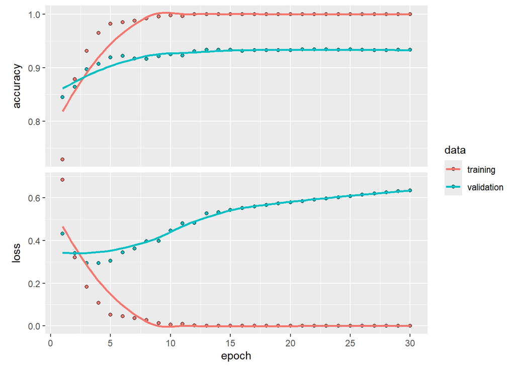

```r
plot(history)
```

Dal grafico si nota chiaramente che il modello tende ad overfittare, la loss del validation rimane alta e tende addirittura a crescere dopo la 10° epoca circa. E’ possibile mitigare l’overfitting sapendo che questo fenomeno è dovuto all’utilizzo di CNN troppo complesse su un numero limitato di immagini, dunque la modifica più immediata da effettuare è ridurre la complessità della CNN. Di conseguenza, per il secondo modello di CNN si procede sia con l’eliminazione del primo layer convoluzionale, sia con la riduzione del numero di neuroni nel layer fully connected finale, passando da 216 a 128 nodi. Inoltre, è stato introdotto un *dropout* con un rate pari a 0.5.

La speranza è che la rete sia contemporaneamente in grado di cogliere elevati dettagli delle immagini presenti nel validation set, ma sia anche sufficientemente flessibile da riuscire e generallizare bene.

```r
model_drop<- keras_model_sequential() %>%
  layer_rescaling(1/255, input_shape = c(150,150,1)) %>%
  layer_conv_2d(filters=64,kernel_size=c(3,3),activation='relu')%>%
  layer_max_pooling_2d(pool_size=c(2,2))%>%
  layer_conv_2d(filters=128,kernel_size=c(3,3),activation='relu')%>%
  layer_flatten()%>%
  layer_dense(units=128,activation='relu')%>%
  layer_dropout(rate=0.5)%>%   # inserisco dropout
  layer_dense(units=4,activation='softmax')

model_drop%>% compile(
  optimizer=c('adam'),
  loss=c('categorical_crossentropy'),
  metrics=c('accuracy')
)

history_drop<-model_drop%>% fit(
  train_ds,
  epochs = 30,
  validation_data=val_ds
)
```

```
## 154/154 - 123s - 796ms/step - accuracy: 0.6569 - loss: 0.9563 - val_accuracy: 0.8387 - val_loss: 0.4551
## 154/154 - 117s - 760ms/step - accuracy: 0.8317 - loss: 0.4404 - val_accuracy: 0.8596 - val_loss: 0.3865
## 154/154 - 117s - 758ms/step - accuracy: 0.8936 - loss: 0.2877 - val_accuracy: 0.8880 - val_loss: 0.2840
## 154/154 - 117s - 760ms/step - accuracy: 0.9241 - loss: 0.2052 - val_accuracy: 0.8966 - val_loss: 0.2624
## 154/154 - 117s - 758ms/step - accuracy: 0.9430 - loss: 0.1536 - val_accuracy: 0.9137 - val_loss: 0.2758
## 154/154 - 116s - 753ms/step - accuracy: 0.9605 - loss: 0.1149 - val_accuracy: 0.9118 - val_loss: 0.2917
## 154/154 - 117s - 757ms/step - accuracy: 0.9646 - loss: 0.0941 - val_accuracy: 0.9222 - val_loss: 0.3157
## 154/154 - 117s - 760ms/step - accuracy: 0.9752 - loss: 0.0726 - val_accuracy: 0.9137 - val_loss: 0.3830
## 154/154 - 117s - 762ms/step - accuracy: 0.9760 - loss: 0.0640 - val_accuracy: 0.9099 - val_loss: 0.4050
## 154/154 - 116s - 753ms/step - accuracy: 0.9821 - loss: 0.0480 - val_accuracy: 0.9137 - val_loss: 0.3780
## 154/154 - 116s - 753ms/step - accuracy: 0.9829 - loss: 0.0461 - val_accuracy: 0.9175 - val_loss: 0.4326
## 154/154 - 117s - 760ms/step - accuracy: 0.9831 - loss: 0.0473 - val_accuracy: 0.9194 - val_loss: 0.3363
## 154/154 - 117s - 759ms/step - accuracy: 0.9813 - loss: 0.0512 - val_accuracy: 0.9118 - val_loss: 0.4522
## 154/154 - 117s - 760ms/step - accuracy: 0.9858 - loss: 0.0422 - val_accuracy: 0.9288 - val_loss: 0.4040
## 154/154 - 116s - 754ms/step - accuracy: 0.9902 - loss: 0.0260 - val_accuracy: 0.9184 - val_loss: 0.4303
## 154/154 - 116s - 751ms/step - accuracy: 0.9902 - loss: 0.0324 - val_accuracy: 0.9269 - val_loss: 0.3951
## 154/154 - 117s - 757ms/step - accuracy: 0.9912 - loss: 0.0251 - val_accuracy: 0.9269 - val_loss: 0.5281
## 154/154 - 116s - 754ms/step - accuracy: 0.9933 - loss: 0.0191 - val_accuracy: 0.9203 - val_loss: 0.5169
## 154/154 - 116s - 755ms/step - accuracy: 0.9919 - loss: 0.0227 - val_accuracy: 0.9260 - val_loss: 0.4715
## 154/154 - 116s - 753ms/step - accuracy: 0.9923 - loss: 0.0206 - val_accuracy: 0.9231 - val_loss: 0.4601
## 154/154 - 116s - 751ms/step - accuracy: 0.9898 - loss: 0.0272 - val_accuracy: 0.9269 - val_loss: 0.3727
## 154/154 - 116s - 752ms/step - accuracy: 0.9923 - loss: 0.0278 - val_accuracy: 0.9213 - val_loss: 0.4726
## 154/154 - 116s - 755ms/step - accuracy: 0.9876 - loss: 0.0346 - val_accuracy: 0.9222 - val_loss: 0.4019
## 154/154 - 116s - 755ms/step - accuracy: 0.9917 - loss: 0.0269 - val_accuracy: 0.9250 - val_loss: 0.5450
## 154/154 - 116s - 752ms/step - accuracy: 0.9925 - loss: 0.0205 - val_accuracy: 0.9165 - val_loss: 0.4227
## 154/154 - 116s - 755ms/step - accuracy: 0.9902 - loss: 0.0242 - val_accuracy: 0.9298 - val_loss: 0.4311
## 154/154 - 117s - 758ms/step - accuracy: 0.9951 - loss: 0.0156 - val_accuracy: 0.9345 - val_loss: 0.4751
## 154/154 - 118s - 763ms/step - accuracy: 0.9961 - loss: 0.0138 - val_accuracy: 0.9260 - val_loss: 0.5098
## 154/154 - 116s - 755ms/step - accuracy: 0.9941 - loss: 0.0162 - val_accuracy: 0.9213 - val_loss: 0.5668
## 154/154 - 116s - 751ms/step - accuracy: 0.9925 - loss: 0.0231 - val_accuracy: 0.9222 - val_loss: 0.5298
```

```r
summary(model_drop)
```

```
## Model: "sequential_1"
## +------------------------------------------------------------------------------
## ¦ Layer (type)                      ¦ Output Shape             ¦       Param #
## +-----------------------------------+--------------------------+---------------
## ¦ rescaling_1 (Rescaling)           ¦ (None, 150, 150, 1)      ¦             0
## +-----------------------------------+--------------------------+---------------
## ¦ conv2d_3 (Conv2D)                 ¦ (None, 148, 148, 64)     ¦           640
## +-----------------------------------+--------------------------+---------------
## ¦ max_pooling2d_2 (MaxPooling2D)    ¦ (None, 74, 74, 64)       ¦             0
## +-----------------------------------+--------------------------+---------------
## ¦ conv2d_4 (Conv2D)                 ¦ (None, 72, 72, 128)      ¦        73,856
## +-----------------------------------+--------------------------+---------------
## ¦ flatten_1 (Flatten)               ¦ (None, 663552)           ¦             0
## +-----------------------------------+--------------------------+---------------
## ¦ dense_2 (Dense)                   ¦ (None, 128)              ¦    84,934,784
## +-----------------------------------+--------------------------+---------------
## ¦ dropout (Dropout)                 ¦ (None, 128)              ¦             0
## +-----------------------------------+--------------------------+---------------
## ¦ dense_3 (Dense)                   ¦ (None, 4)                ¦           516
## +------------------------------------------------------------------------------
##  Total params: 255,029,390 (972.86 MB)
##  Trainable params: 85,009,796 (324.29 MB)
##  Non-trainable params: 0 (0.00 B)
##  Optimizer params: 170,019,594 (648.57 MB)
```

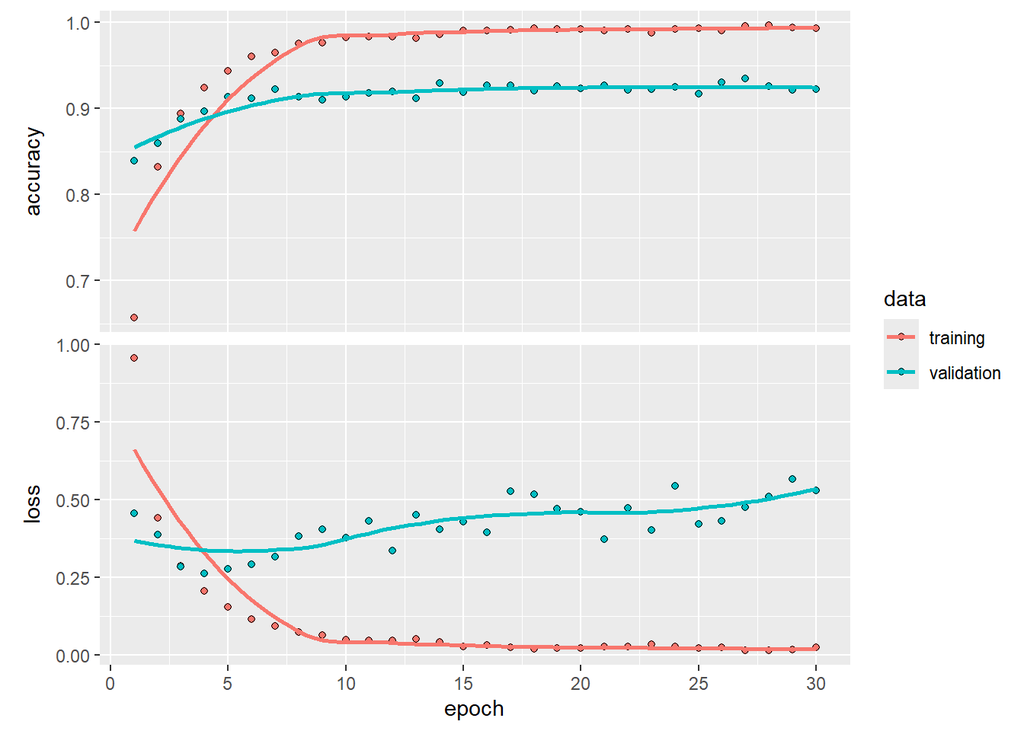

```r
plot(history_drop)
```

Dal grafico si nota ancora l’effetto di un elevato overfitting.

Confrontando la complessità delle due reti si osserva che, sebbene il secondo modello sia meno profondo rispetto al modello baseline, dato il suo numero inferiore di layer, questo presenti un numero estremamente superiori di parametri.

Confrontando il *numero totale di parametri* delle due reti:

- *Parametri Mod. Baseline* = 96,164,534
- *Parametri Mod. Attuale* = 255,029,390

Non riuscendo a gestire intuitivamente il rapporto tra numero di layer e numero di parametri della rete, si è scelto di seguire la strada complementare per la mitigazione dell’overfitting: ovvero *aumentare l’informazione campionaria* mediante la tecnica della *data augmentation*.

In particolare si implementano e si analizzano due versioni diverse di questa tecnica, una più *‘pesante’*, con modifiche più impattanti sulle immagini e una più *‘leggera’*.

In seguito si presentano le caratteristiche delle due versione:

Le aspettative sono duplici:

- Si spera di mitigare l’effetto dell’overfitting aumentando la *varietà* delle immagini che il modello osserverà, nella speranza che questo possa aumentare la sua capacità di generalizzazione.
- Si vuole osservare l’impatto che la data augmentation ha su immagini mediche, queste infatti incorporano un informazione clinica che deve essere preservata, in caso contrario il modello peggiorerà notevolmente.

```r
########### DEFINISCO LE DUE VERSIONE DI AUGMENTATION  ############

# 1. AUGMENTATION PESANTE #
data_augmentation <- keras_model_sequential() %>%
  layer_random_rotation(0.5) %>%       # ± 5° rotazione
  layer_random_zoom(0.10) %>%           # ±10% zoom
  layer_random_translation(height_factor=0.02, width_factor=0.02) %>%  # ±2% shift
  layer_random_brightness(factor=0.05) %>%
  layer_random_contrast(factor = 0.05)

# 2. AUGMENTATION LEGGERA
data_augmentation_2 <- keras_model_sequential() %>%
  layer_random_rotation(0.03) %>%       # ±3° rotazione
  layer_random_zoom(0.05)           # ±5% zoom

###### ALLENO MODELLO CON AUGMENTATION PESANTE ######

model_drop_2<- keras_model_sequential() %>%
  layer_rescaling(1/255, input_shape = c(150,150,1)) %>%
  data_augmentation %>%
  layer_conv_2d(filters=32,kernel_size=c(3,3),activation='relu')%>%
  layer_max_pooling_2d(pool_size=c(2,2))%>%
  layer_conv_2d(filters=64,kernel_size=c(3,3),activation='relu')%>%
  layer_max_pooling_2d(pool_size=c(2,2))%>%
  layer_conv_2d(filters=128,kernel_size=c(3,3),activation='relu')%>%
  layer_flatten()%>%
  layer_dense(units=128,activation='relu')%>%
  layer_dropout(rate=0.5)%>%   # inserisco dropout
  layer_dense(units=4,activation='softmax')

model_drop_2%>% compile(
  optimizer=c('adam'), # da provare anche Adam
  loss=c('categorical_crossentropy'),
  metrics=c('accuracy')
)

history_drop_2<-model_drop_2%>% fit(
  train_ds,
  epochs = 30,
  validation_data=val_ds
)
```

```
## 154/154 - 50s - 322ms/step - accuracy: 0.2745 - loss: 1.7278 - val_accuracy: 0.2846 - val_loss: 1.3843
## 154/154 - 47s - 304ms/step - accuracy: 0.2847 - loss: 1.3853 - val_accuracy: 0.2846 - val_loss: 1.3820
## 154/154 - 47s - 305ms/step - accuracy: 0.2847 - loss: 1.3857 - val_accuracy: 0.2846 - val_loss: 1.3643
## 154/154 - 47s - 306ms/step - accuracy: 0.2818 - loss: 1.3832 - val_accuracy: 0.2846 - val_loss: 1.3294
## 154/154 - 48s - 312ms/step - accuracy: 0.2851 - loss: 1.3825 - val_accuracy: 0.2846 - val_loss: 1.3355
## 154/154 - 47s - 308ms/step - accuracy: 0.2845 - loss: 1.4007 - val_accuracy: 0.2846 - val_loss: 1.3155
## 154/154 - 48s - 309ms/step - accuracy: 0.2837 - loss: 1.3860 - val_accuracy: 0.2837 - val_loss: 1.3199
## 154/154 - 47s - 306ms/step - accuracy: 0.2849 - loss: 1.3827 - val_accuracy: 0.2837 - val_loss: 1.3000
## 154/154 - 47s - 305ms/step - accuracy: 0.2857 - loss: 1.3842 - val_accuracy: 0.2846 - val_loss: 1.3565
## 154/154 - 47s - 305ms/step - accuracy: 0.2841 - loss: 1.4124 - val_accuracy: 0.2846 - val_loss: 1.3743
## 154/154 - 47s - 305ms/step - accuracy: 0.2845 - loss: 1.4064 - val_accuracy: 0.2846 - val_loss: 1.3796
## 154/154 - 47s - 308ms/step - accuracy: 0.2847 - loss: 1.3840 - val_accuracy: 0.2856 - val_loss: 1.3534
## 154/154 - 48s - 309ms/step - accuracy: 0.2857 - loss: 1.4912 - val_accuracy: 0.2846 - val_loss: 1.3806
## 154/154 - 47s - 308ms/step - accuracy: 0.2845 - loss: 1.3905 - val_accuracy: 0.2846 - val_loss: 1.3741
## 154/154 - 48s - 311ms/step - accuracy: 0.2845 - loss: 1.4092 - val_accuracy: 0.2846 - val_loss: 1.3818
## 154/154 - 47s - 308ms/step - accuracy: 0.2849 - loss: 1.3832 - val_accuracy: 0.2846 - val_loss: 1.3769
## 154/154 - 48s - 310ms/step - accuracy: 0.2849 - loss: 1.3825 - val_accuracy: 0.2846 - val_loss: 1.3737
## 154/154 - 47s - 307ms/step - accuracy: 0.2849 - loss: 1.3832 - val_accuracy: 0.2846 - val_loss: 1.3563
## 154/154 - 47s - 306ms/step - accuracy: 0.2847 - loss: 1.3994 - val_accuracy: 0.2818 - val_loss: 1.3728
## 154/154 - 47s - 306ms/step - accuracy: 0.2851 - loss: 1.4721 - val_accuracy: 0.2837 - val_loss: 1.3785
## 154/154 - 47s - 307ms/step - accuracy: 0.2845 - loss: 1.3828 - val_accuracy: 0.2846 - val_loss: 1.3532
## 154/154 - 48s - 309ms/step - accuracy: 0.2849 - loss: 1.3831 - val_accuracy: 0.2846 - val_loss: 1.3017
## 154/154 - 47s - 308ms/step - accuracy: 0.2849 - loss: 1.3823 - val_accuracy: 0.2846 - val_loss: 1.2757
## 154/154 - 47s - 308ms/step - accuracy: 0.2843 - loss: 1.3822 - val_accuracy: 0.2922 - val_loss: 1.5617
## 154/154 - 47s - 308ms/step - accuracy: 0.2851 - loss: 1.3813 - val_accuracy: 0.2846 - val_loss: 4.5349
## 154/154 - 47s - 308ms/step - accuracy: 0.2845 - loss: 1.3832 - val_accuracy: 0.3226 - val_loss: 1.2981
## 154/154 - 47s - 307ms/step - accuracy: 0.2851 - loss: 1.3818 - val_accuracy: 0.2770 - val_loss: 1.3736
## 154/154 - 47s - 306ms/step - accuracy: 0.2849 - loss: 1.3830 - val_accuracy: 0.2998 - val_loss: 1.2147
## 154/154 - 47s - 306ms/step - accuracy: 0.2849 - loss: 1.3827 - val_accuracy: 0.2865 - val_loss: 1.2165
## 154/154 - 47s - 306ms/step - accuracy: 0.2847 - loss: 1.3834 - val_accuracy: 0.2846 - val_loss: 1.3820
```

```r
summary(model_drop_2)
```

```
## Model: "sequential_4"
## +------------------------------------------------------------------------------
## ¦ Layer (type)                      ¦ Output Shape             ¦       Param #
## +-----------------------------------+--------------------------+---------------
## ¦ rescaling_2 (Rescaling)           ¦ (None, 150, 150, 1)      ¦             0
## +-----------------------------------+--------------------------+---------------
## ¦ sequential_2 (Sequential)         ¦ (None, 150, 150, 1)      ¦             0
## +-----------------------------------+--------------------------+---------------
## ¦ conv2d_5 (Conv2D)                 ¦ (None, 148, 148, 32)     ¦           320
## +-----------------------------------+--------------------------+---------------
## ¦ max_pooling2d_3 (MaxPooling2D)    ¦ (None, 74, 74, 32)       ¦             0
## +-----------------------------------+--------------------------+---------------
## ¦ conv2d_6 (Conv2D)                 ¦ (None, 72, 72, 64)       ¦        18,496
## +-----------------------------------+--------------------------+---------------
## ¦ max_pooling2d_4 (MaxPooling2D)    ¦ (None, 36, 36, 64)       ¦             0
## +-----------------------------------+--------------------------+---------------
## ¦ conv2d_7 (Conv2D)                 ¦ (None, 34, 34, 128)      ¦        73,856
## +-----------------------------------+--------------------------+---------------
## ¦ flatten_2 (Flatten)               ¦ (None, 147968)           ¦             0
## +-----------------------------------+--------------------------+---------------
## ¦ dense_4 (Dense)                   ¦ (None, 128)              ¦    18,940,032
## +-----------------------------------+--------------------------+---------------
## ¦ dropout_1 (Dropout)               ¦ (None, 128)              ¦             0
## +-----------------------------------+--------------------------+---------------
## ¦ dense_5 (Dense)                   ¦ (None, 4)                ¦           516
## +------------------------------------------------------------------------------
##  Total params: 57,099,662 (217.82 MB)
##  Trainable params: 19,033,220 (72.61 MB)
##  Non-trainable params: 0 (0.00 B)
##  Optimizer params: 38,066,442 (145.21 MB)
```

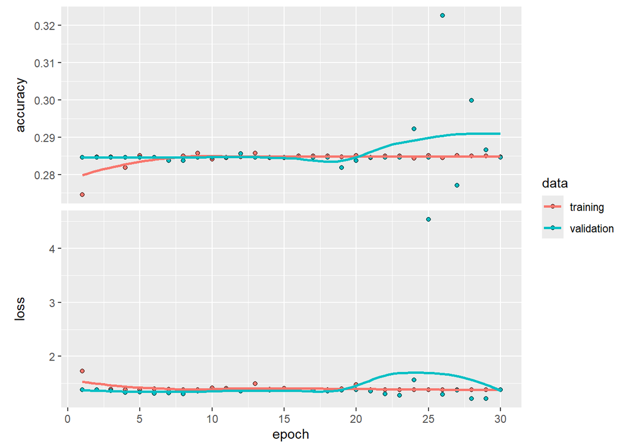

```r
plot(history_drop_2)
```

E’ possibile chiaramente notare che il timore presentato in precedenza sia stato confermato. La *data augmentation pesante* ha distrutto l’informazione clinica delle immagini. Il modello ottenuto risulta essere completamento errato ed inutilizzabile. Si procede ora con la *data augmentation leggera*.

```r
#############   AUGMENTATION LEGGERA  #########

data_augmentation_2 <- keras_model_sequential() %>%
  layer_random_rotation(0.03) %>%       # ±3° rotazione
  layer_random_zoom(0.05)           # ±5% zoom

model_drop_3<- keras_model_sequential() %>%
  layer_rescaling(1/255, input_shape = c(150,150,1)) %>%
  data_augmentation_2 %>%
  layer_conv_2d(filters=32,kernel_size=c(3,3),activation='relu')%>%
  layer_max_pooling_2d(pool_size=c(2,2))%>%
  layer_conv_2d(filters=64,kernel_size=c(3,3),activation='relu')%>%
  layer_max_pooling_2d(pool_size=c(2,2))%>%
  layer_conv_2d(filters=128,kernel_size=c(3,3),activation='relu')%>%
  layer_flatten()%>%
  layer_dense(units=128,activation='relu')%>%
  layer_dropout(rate=0.5)%>%   # inserisco dropout
  layer_dense(units=4,activation='softmax')

model_drop_3%>% compile(
  optimizer=c('adam'), # da provare anche Adam
  loss=c('categorical_crossentropy'),
  metrics=c('accuracy')
)

history_drop_3<-model_drop_3%>% fit(
  train_ds,
  epochs = 30,
  validation_data=val_ds
)
```

```
## 154/154 - 48s - 314ms/step - accuracy: 0.6752 - loss: 0.7823 - val_accuracy: 0.7410 - val_loss: 0.7112
## 154/154 - 46s - 298ms/step - accuracy: 0.8008 - loss: 0.5275 - val_accuracy: 0.8311 - val_loss: 0.4663
## 154/154 - 46s - 300ms/step - accuracy: 0.8398 - loss: 0.4173 - val_accuracy: 0.8416 - val_loss: 0.4703
## 154/154 - 46s - 300ms/step - accuracy: 0.8681 - loss: 0.3574 - val_accuracy: 0.8672 - val_loss: 0.3474
## 154/154 - 46s - 299ms/step - accuracy: 0.8875 - loss: 0.2876 - val_accuracy: 0.8909 - val_loss: 0.2935
## 154/154 - 47s - 303ms/step - accuracy: 0.8995 - loss: 0.2749 - val_accuracy: 0.9089 - val_loss: 0.2584
## 154/154 - 47s - 303ms/step - accuracy: 0.9129 - loss: 0.2297 - val_accuracy: 0.8833 - val_loss: 0.3566
## 154/154 - 47s - 303ms/step - accuracy: 0.9196 - loss: 0.2120 - val_accuracy: 0.9099 - val_loss: 0.2635
## 154/154 - 47s - 302ms/step - accuracy: 0.9269 - loss: 0.1900 - val_accuracy: 0.9194 - val_loss: 0.2641
## 154/154 - 46s - 301ms/step - accuracy: 0.9394 - loss: 0.1682 - val_accuracy: 0.9146 - val_loss: 0.2392
## 154/154 - 46s - 301ms/step - accuracy: 0.9465 - loss: 0.1524 - val_accuracy: 0.9194 - val_loss: 0.2879
## 154/154 - 46s - 300ms/step - accuracy: 0.9453 - loss: 0.1466 - val_accuracy: 0.9231 - val_loss: 0.2729
## 154/154 - 46s - 301ms/step - accuracy: 0.9532 - loss: 0.1275 - val_accuracy: 0.9203 - val_loss: 0.2814
## 154/154 - 46s - 300ms/step - accuracy: 0.9542 - loss: 0.1304 - val_accuracy: 0.9241 - val_loss: 0.2487
## 154/154 - 46s - 300ms/step - accuracy: 0.9538 - loss: 0.1203 - val_accuracy: 0.9478 - val_loss: 0.2290
## 154/154 - 46s - 301ms/step - accuracy: 0.9579 - loss: 0.1228 - val_accuracy: 0.9374 - val_loss: 0.2418
## 154/154 - 46s - 300ms/step - accuracy: 0.9636 - loss: 0.0991 - val_accuracy: 0.9393 - val_loss: 0.2419
## 154/154 - 46s - 299ms/step - accuracy: 0.9695 - loss: 0.0872 - val_accuracy: 0.9450 - val_loss: 0.2282
## 154/154 - 46s - 301ms/step - accuracy: 0.9664 - loss: 0.0941 - val_accuracy: 0.9269 - val_loss: 0.2905
## 154/154 - 46s - 300ms/step - accuracy: 0.9685 - loss: 0.0868 - val_accuracy: 0.9421 - val_loss: 0.2621
## 154/154 - 46s - 299ms/step - accuracy: 0.9746 - loss: 0.0680 - val_accuracy: 0.9469 - val_loss: 0.2392
## 154/154 - 46s - 301ms/step - accuracy: 0.9729 - loss: 0.0767 - val_accuracy: 0.9393 - val_loss: 0.2691
## 154/154 - 46s - 300ms/step - accuracy: 0.9735 - loss: 0.0707 - val_accuracy: 0.9383 - val_loss: 0.3088
## 154/154 - 47s - 302ms/step - accuracy: 0.9742 - loss: 0.0682 - val_accuracy: 0.9440 - val_loss: 0.2661
## 154/154 - 49s - 317ms/step - accuracy: 0.9762 - loss: 0.0707 - val_accuracy: 0.9469 - val_loss: 0.2404
## 154/154 - 49s - 319ms/step - accuracy: 0.9780 - loss: 0.0652 - val_accuracy: 0.9488 - val_loss: 0.2851
## 154/154 - 49s - 316ms/step - accuracy: 0.9721 - loss: 0.0779 - val_accuracy: 0.9507 - val_loss: 0.2891
## 154/154 - 49s - 320ms/step - accuracy: 0.9784 - loss: 0.0600 - val_accuracy: 0.9175 - val_loss: 0.3837
## 154/154 - 49s - 316ms/step - accuracy: 0.9811 - loss: 0.0527 - val_accuracy: 0.9583 - val_loss: 0.2374
## 154/154 - 49s - 317ms/step - accuracy: 0.9829 - loss: 0.0483 - val_accuracy: 0.9526 - val_loss: 0.2568
```

```r
summary(model_drop_3)
```

```
## Model: "sequential_6"
## +------------------------------------------------------------------------------
## ¦ Layer (type)                      ¦ Output Shape             ¦       Param #
## +-----------------------------------+--------------------------+---------------
## ¦ rescaling_3 (Rescaling)           ¦ (None, 150, 150, 1)      ¦             0
## +-----------------------------------+--------------------------+---------------
## ¦ sequential_5 (Sequential)         ¦ (None, 150, 150, 1)      ¦             0
## +-----------------------------------+--------------------------+---------------
## ¦ conv2d_8 (Conv2D)                 ¦ (None, 148, 148, 32)     ¦           320
## +-----------------------------------+--------------------------+---------------
## ¦ max_pooling2d_5 (MaxPooling2D)    ¦ (None, 74, 74, 32)       ¦             0
## +-----------------------------------+--------------------------+---------------
## ¦ conv2d_9 (Conv2D)                 ¦ (None, 72, 72, 64)       ¦        18,496
## +-----------------------------------+--------------------------+---------------
## ¦ max_pooling2d_6 (MaxPooling2D)    ¦ (None, 36, 36, 64)       ¦             0
## +-----------------------------------+--------------------------+---------------
## ¦ conv2d_10 (Conv2D)                ¦ (None, 34, 34, 128)      ¦        73,856
## +-----------------------------------+--------------------------+---------------
## ¦ flatten_3 (Flatten)               ¦ (None, 147968)           ¦             0
## +-----------------------------------+--------------------------+---------------
## ¦ dense_6 (Dense)                   ¦ (None, 128)              ¦    18,940,032
## +-----------------------------------+--------------------------+---------------
## ¦ dropout_2 (Dropout)               ¦ (None, 128)              ¦             0
## +-----------------------------------+--------------------------+---------------
## ¦ dense_7 (Dense)                   ¦ (None, 4)                ¦           516
## +------------------------------------------------------------------------------
##  Total params: 57,099,662 (217.82 MB)
##  Trainable params: 19,033,220 (72.61 MB)
##  Non-trainable params: 0 (0.00 B)
##  Optimizer params: 38,066,442 (145.21 MB)
```

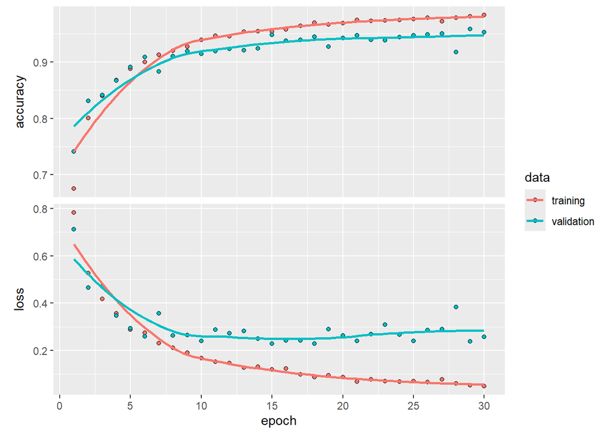

```r
plot(history_drop_3)
```

Si nota chiaramente come, con questa versione di data augmentation, le performance del modello siano decisamente migliorate, al punto tale da poter essere considerato il migliore fino a questo punto.

Il modello presenta comunque overfitting ma in modo decisamente più mitigato rispetto ai precedenti.

```r
# carico le immagini
train_ds <- image_dataset_from_directory(
  "C:/Users/AP869597/Desktop/progetto_learning/train",
  image_size = c(150,150),
  batch_size = 32,
  color_mode = "grayscale",
  label_mode = "categorical",
  shuffle=T
)
```

```
## Found 4914 files belonging to 4 classes.
```

```r
# Provo gli effetti delle due data augmentation sulla 16-esima immagine  #

fnames<-list.files("C:/Users/AP869597/Desktop/progetto_learning/train/glioma",full.name=T)
img_path<-fnames[[16]]

######   1. immagine di Glioma      ##############

img <- image_load(img_path, target_size = c(150,150))
img_array <- image_to_array(img)
img_array <- apply(img_array, c(1,2), mean)

img_array <- array_reshape(img_array, c(1,150,150,1)) # (batch,height,width,channels)

dim(img_array)
```

```
## [1]   1 150 150   1
```

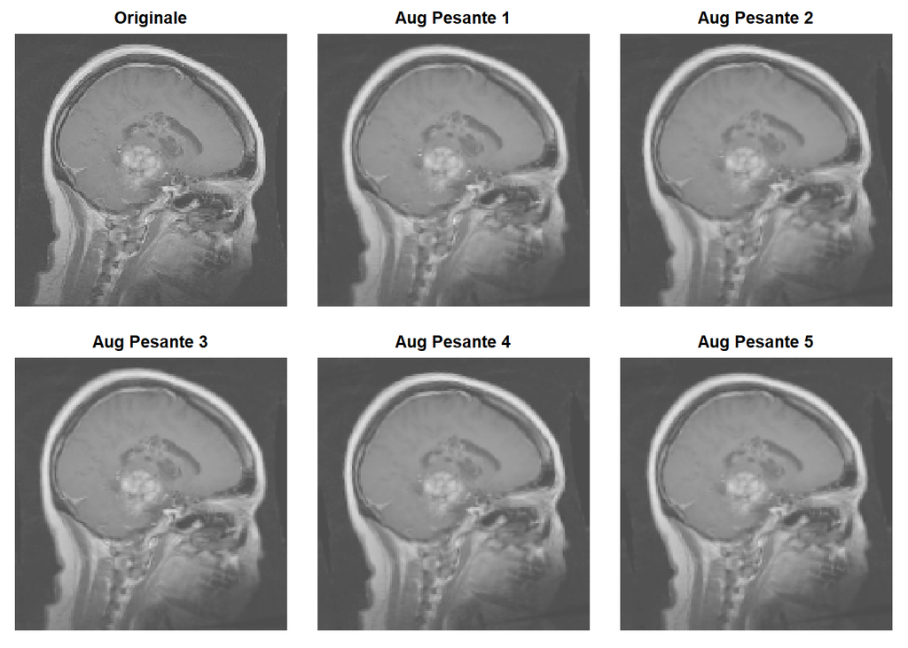

```r
input_tensor <- layer_input(shape = c(150,150,1))

outputs_aug <- input_tensor %>% data_augmentation_2
outputs_aug_2<-input_tensor %>% data_augmentation
augmenter <- keras_model(
  inputs = input_tensor,
  outputs = outputs_aug
)

###  Augmentation Pesante  ###
augmenter_2<-keras_model(
  inputs = input_tensor,
  outputs = outputs_aug
)
op <- par(mfrow = c(2,3), pty = "s", mar = c(1,0,2,0))

########## VISUALIZZAZIONE #####################

# Mostra immagine originale

image(
  t(apply(img_array[1,,,1], 2, rev)),
  col = gray.colors(256),
  axes = FALSE,
  main = "Originale"
)

########## prima aumentazione pesante ######

for (i in 1:5) {
  img_aug <- augmenter_2(img_array, training = TRUE)
  img_aug <- as.array(img_aug)

  image(
    t(apply(img_aug[1,,,1], 2, rev)),
    col = gray.colors(256),
    axes = FALSE,
    main = paste("Aug Pesante", i)
  )
}
```

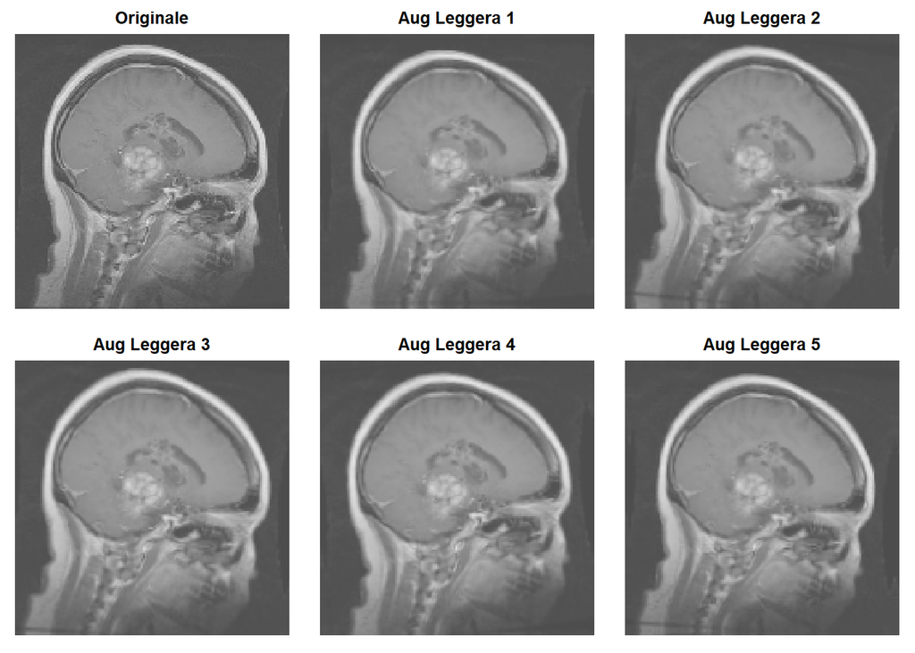

```r
par(op)

######## processo identico ma con augmentazione leggera #######

op <- par(mfrow = c(2,3), pty = "s", mar = c(1,0,2,0))

image(
  t(apply(img_array[1,,,1], 2, rev)),
  col = gray.colors(256),
  axes = FALSE,
  main = "Originale"
)

for (i in 1:5) {
  img_aug <- augmenter(img_array, training = TRUE)
  img_aug <- as.array(img_aug)

  image(
    t(apply(img_aug[1,,,1], 2, rev)),
    col = gray.colors(256),
    axes = FALSE,
    main = paste("Aug Leggera", i)
  )
}
```

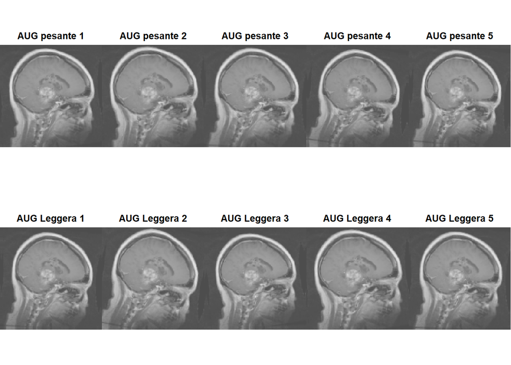

```r
#############CONFRONTO LE DUE AUGMENTAZIONI ###########
op <- par(mfrow = c(2,5), pty = "s", mar = c(1,0,2,0))

# Prima riga: augmenter_2 (pesante)
for (i in 1:5) {
  img_aug <- augmenter_2(img_array, training = TRUE)
  img_aug <- as.array(img_aug)
  image(t(apply(img_aug[1,,,1], 2, rev)),
        col = gray.colors(256),
        axes = FALSE,
        main = paste("AUG pesante", i))
}

# Seconda riga: augmenter (leggera)
for (i in 1:5) {
  img_aug <- augmenter(img_array, training = TRUE)
  img_aug <- as.array(img_aug)
  image(t(apply(img_aug[1,,,1], 2, rev)),
        col = gray.colors(256),
        axes = FALSE,
        main = paste("AUG Leggera", i))
}
```

```r
par(op)
```

Per le performance ottenute, si potrebbe essere già soddisfatti con l’ultimo modello ottenuto. Tuttavia si prova ad utilizzare un operazione di *Transfer-Learning* per la costruzione di un ultimo modello.

In questo caso verrà *‘importata’* la rete già allenata ResNet50, i cui pesi sono stati già precedentemente allenati sul dataset *ImageNet*. Inoltre vengono congelati i pesi iniziali della rete in modo da conservare la capacità di distinguere bordi, forme e semplici texture per poi addestrare i layer finali del modello sul mio dataset specifico. Unitamente a ciò si decide di non includere il classificatore associato a *ImageNet*, progettato per 1000 classi, ma di allenare una rete neurale specificatamente sul dataset. Questa andrà a costituire l’elemeto finale della nuova CNN.

Una nota importante è che il dataset *ImageNet* sul quale è stata pre-allenata la rete convoluzionale poi importata, contiene immagini RGB, mentre il dataset utilizzaro è formato da immagini MRI dunque in bianco e nero.

E’ dunque necessario uniformare il formato delle immagini e di conseguenza dei tensori che il modello riceverà come input. Dalla letteratura è spesso consigliato trasformare le immagini da bianco e nero in RGB, piuttosto che il contrario. Questo perchè la rete pre-addestrata si aspetta input a tre canali.

Per effettuare questa operazione, ogni immagine in bianco e nero viene replicata lungo i tre canali colore, generando un’immagine pseudo-RGB in cui ciascun canale contiene la stessa intensità dell’immagine originale.

Formalmente, se $I \in \mathbb{R}^{H \times W \times 1}$ rappresenta l’immagine MRI originale, l’immagine trasformata $I_{\text{RGB}} \in \mathbb{R}^{H \times W \times 3}$ si ottiene tramite la concatenazione lungo l’asse dei tre canali:
$$I_{\text{RGB}} = \text{concat}(I, I, I)$$

Questa trasformazione preserva completamente l’informazione originale e rende le immagini compatibili con la rete convoluzionale pre-addestrata, consentendo di sfruttare le feature già apprese senza introdurre alterazioni artificiali.

Infine, in questo modello non viene applicata una riscalatura dei pixel nell’intervallo [0,1], in quanto è doveroso applicare applicare le medesime operazioni di pre-processing che sono state effettuate dalla rete pre addestrata ResNet50 su *ImageNet*. Viene dunque usata per la medisima funzione di pre-processing associata al modello pre-allenato, in questo modo si garantisce che il modello finale venga addestrato in modo coerente con il medesimo formato di immagini su cui la rete ha originariamente appreso le proprie rappresentazioni.

```r
###### PRE-TRAINED CONVNET  #######
# Da letteratura per i dataset medicali è suggerito scelgliere res_net50 #
# conversione bianco/nero -> RGB ##
# copiamo il valore del canale grayscale su tutti e 3 i canali
# Se un pixel ha valore 120 in grayscale, dopo la conversione diventa [120, 120, 120] in RGB
# In questo modo si mantiene la stessa luminosità e contrasto, ma ora è compatibile con modelli #pre-trained ImageNet

conv_base <- application_resnet50(
  weights = 'imagenet',
  include_top = FALSE,
  input_shape = c(150, 150, 3)
)
freeze_weights(conv_base)  # blocca i pesi dei primi layer base

###  Funzione per convertire grigio -> RGB ###
gray_to_rgb <- function(x, y) {
  x <- tf$concat(list(x, x, x), axis = -1L)  # replica il canale
  list(x, y)
}

### 3. Trasformazione delle immagini in RGB ####
train_ds_to_rgb <- train_ds %>% tf$data$Dataset$map(gray_to_rgb)
val_ds_to_rgb <- val_ds %>% tf$data$Dataset$map(gray_to_rgb)

### 4. Costruzione modello ##
inputs <- layer_input(shape = c(150, 150, 3))

x <- inputs %>%
  data_augmentation_2 %>%                          # layer di data augmentation
  tf$keras$applications$resnet50$preprocess_input()  # preprocessing ImageNet

x <- conv_base(x, training = FALSE) %>%
  layer_global_average_pooling_2d() %>%
  layer_dense(128, activation = "relu") %>%
  layer_dropout(0.5) %>%
  layer_dense(4, activation = "softmax")            # 4 classi

model_preconv <- keras_model(inputs, x)

model_preconv %>% compile(
  optimizer = 'adam',
  loss = "categorical_crossentropy",
  metrics = c("accuracy")
)

history_preconv <- model_preconv %>% fit(
  train_ds_to_rgb,
  validation_data = val_ds_to_rgb,
  epochs = 30,
  verbose = 2
)
```

```
## 154/154 - 124s - 805ms/step - accuracy: 0.7503 - loss: 0.6574 - val_accuracy: 0.8520 - val_loss: 0.3694
## 154/154 - 139s - 900ms/step - accuracy: 0.8415 - loss: 0.4102 - val_accuracy: 0.8643 - val_loss: 0.3316
## 154/154 - 114s - 742ms/step - accuracy: 0.8677 - loss: 0.3521 - val_accuracy: 0.9042 - val_loss: 0.2509
## 154/154 - 114s - 740ms/step - accuracy: 0.8759 - loss: 0.3129 - val_accuracy: 0.8985 - val_loss: 0.2668
## 154/154 - 114s - 737ms/step - accuracy: 0.8867 - loss: 0.3045 - val_accuracy: 0.9156 - val_loss: 0.2292
## 154/154 - 114s - 741ms/step - accuracy: 0.8948 - loss: 0.2797 - val_accuracy: 0.9080 - val_loss: 0.2290
## 154/154 - 114s - 743ms/step - accuracy: 0.9017 - loss: 0.2490 - val_accuracy: 0.9042 - val_loss: 0.2465
## 154/154 - 114s - 738ms/step - accuracy: 0.9070 - loss: 0.2417 - val_accuracy: 0.9146 - val_loss: 0.2262
## 154/154 - 102s - 665ms/step - accuracy: 0.9111 - loss: 0.2268 - val_accuracy: 0.9051 - val_loss: 0.2577
## 154/154 - 113s - 736ms/step - accuracy: 0.9206 - loss: 0.2183 - val_accuracy: 0.9203 - val_loss: 0.2192
## 154/154 - 113s - 732ms/step - accuracy: 0.9210 - loss: 0.2036 - val_accuracy: 0.9127 - val_loss: 0.2332
## 154/154 - 114s - 741ms/step - accuracy: 0.9178 - loss: 0.2066 - val_accuracy: 0.8966 - val_loss: 0.2858
## 154/154 - 113s - 733ms/step - accuracy: 0.9210 - loss: 0.1975 - val_accuracy: 0.9023 - val_loss: 0.2809
## 154/154 - 113s - 737ms/step - accuracy: 0.9263 - loss: 0.1839 - val_accuracy: 0.9203 - val_loss: 0.2211
## 154/154 - 113s - 735ms/step - accuracy: 0.9237 - loss: 0.2018 - val_accuracy: 0.9250 - val_loss: 0.2405
## 154/154 - 115s - 749ms/step - accuracy: 0.9306 - loss: 0.1784 - val_accuracy: 0.9108 - val_loss: 0.2737
## 154/154 - 115s - 747ms/step - accuracy: 0.9392 - loss: 0.1569 - val_accuracy: 0.9156 - val_loss: 0.2397
## 154/154 - 114s - 741ms/step - accuracy: 0.9361 - loss: 0.1650 - val_accuracy: 0.9194 - val_loss: 0.2335
## 154/154 - 114s - 743ms/step - accuracy: 0.9363 - loss: 0.1685 - val_accuracy: 0.9156 - val_loss: 0.2454
## 154/154 - 113s - 736ms/step - accuracy: 0.9387 - loss: 0.1560 - val_accuracy: 0.9222 - val_loss: 0.2328
## 154/154 - 114s - 743ms/step - accuracy: 0.9457 - loss: 0.1434 - val_accuracy: 0.9156 - val_loss: 0.2520
## 154/154 - 116s - 754ms/step - accuracy: 0.9469 - loss: 0.1382 - val_accuracy: 0.9279 - val_loss: 0.2276
## 154/154 - 115s - 748ms/step - accuracy: 0.9463 - loss: 0.1343 - val_accuracy: 0.9184 - val_loss: 0.2583
## 154/154 - 114s - 738ms/step - accuracy: 0.9467 - loss: 0.1371 - val_accuracy: 0.9279 - val_loss: 0.2222
## 154/154 - 114s - 737ms/step - accuracy: 0.9430 - loss: 0.1407 - val_accuracy: 0.9222 - val_loss: 0.2211
## 154/154 - 113s - 736ms/step - accuracy: 0.9446 - loss: 0.1418 - val_accuracy: 0.9260 - val_loss: 0.2286
## 154/154 - 113s - 736ms/step - accuracy: 0.9469 - loss: 0.1364 - val_accuracy: 0.9231 - val_loss: 0.2241
## 154/154 - 114s - 741ms/step - accuracy: 0.9444 - loss: 0.1376 - val_accuracy: 0.9137 - val_loss: 0.2953
## 154/154 - 115s - 746ms/step - accuracy: 0.9510 - loss: 0.1331 - val_accuracy: 0.9269 - val_loss: 0.2353
## 154/154 - 113s - 733ms/step - accuracy: 0.9514 - loss: 0.1287 - val_accuracy: 0.9345 - val_loss: 0.2317
```

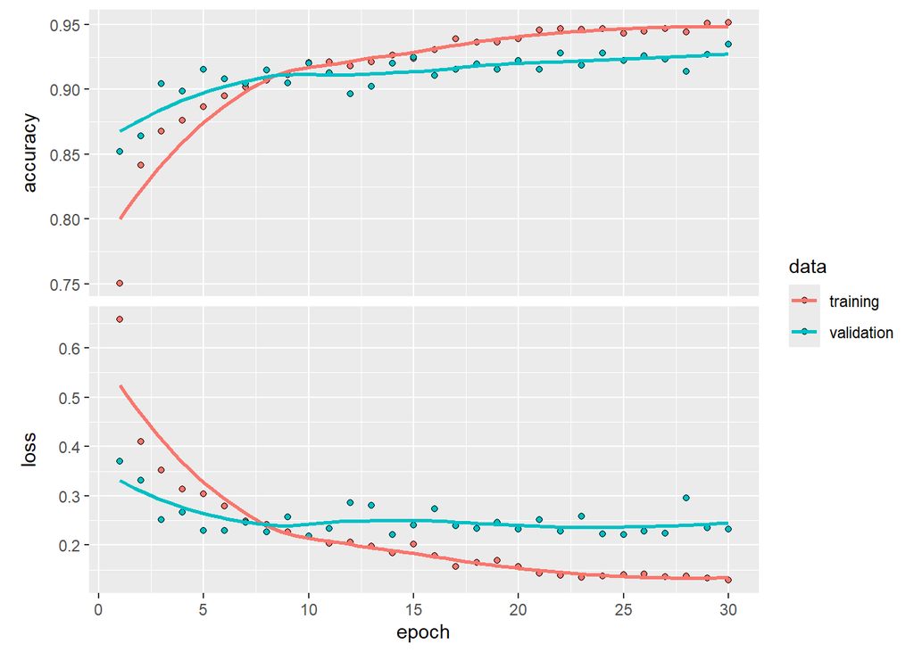

```r
plot(history_preconv)
```

```r
summary(model_preconv)
```

```
## Model: "functional_43"
## +------------------------------------------------------------------------------
## ¦ Layer (type)       ¦ Output Shape     ¦    Param # ¦ Connected to    ¦ Trai…
## +--------------------+------------------+------------+-----------------+-------
## ¦ input_layer_8      ¦ (None, 150, 150, ¦          0 ¦ -               ¦   -
## ¦ (InputLayer)       ¦ 3)               ¦            ¦                 ¦
## +--------------------+------------------+------------+-----------------+-------
## ¦ sequential_5       ¦ (None, 150, 150, ¦          0 ¦ input_layer_8[… ¦   -
## ¦ (Sequential)       ¦ 3)               ¦            ¦                 ¦
## +--------------------+------------------+------------+-----------------+-------
## ¦ get_item (GetItem) ¦ (None, 150, 150) ¦          0 ¦ sequential_5[1… ¦   -
## +--------------------+------------------+------------+-----------------+-------
## ¦ get_item_1         ¦ (None, 150, 150) ¦          0 ¦ sequential_5[1… ¦   -
## ¦ (GetItem)          ¦                  ¦            ¦                 ¦
## +--------------------+------------------+------------+-----------------+-------
## ¦ get_item_2         ¦ (None, 150, 150) ¦          0 ¦ sequential_5[1… ¦   -
## ¦ (GetItem)          ¦                  ¦            ¦                 ¦
## +--------------------+------------------+------------+-----------------+-------
## ¦ stack (Stack)      ¦ (None, 150, 150, ¦          0 ¦ get_item[0][0], ¦   -
## ¦                    ¦ 3)               ¦            ¦ get_item_1[0][… ¦
## ¦                    ¦                  ¦            ¦ get_item_2[0][… ¦
## +--------------------+------------------+------------+-----------------+-------
## ¦ add (Add)          ¦ (None, 150, 150, ¦          0 ¦ stack[0][0]     ¦   -
## ¦                    ¦ 3)               ¦            ¦                 ¦
## +--------------------+------------------+------------+-----------------+-------
## ¦ resnet50           ¦ (None, 5, 5,     ¦ 23,587,712 ¦ add[0][0]       ¦   N
## ¦ (Functional)       ¦ 2048)            ¦            ¦                 ¦
## +--------------------+------------------+------------+-----------------+-------
## ¦ global_average_po… ¦ (None, 2048)     ¦          0 ¦ resnet50[0][0]  ¦   -
## ¦ (GlobalAveragePoo… ¦                  ¦            ¦                 ¦
## +--------------------+------------------+------------+-----------------+-------
## ¦ dense_8 (Dense)    ¦ (None, 128)      ¦    262,272 ¦ global_average… ¦   Y
## +--------------------+------------------+------------+-----------------+-------
## ¦ dropout_3          ¦ (None, 128)      ¦          0 ¦ dense_8[0][0]   ¦   -
## ¦ (Dropout)          ¦                  ¦            ¦                 ¦
## +--------------------+------------------+------------+-----------------+-------
## ¦ dense_9 (Dense)    ¦ (None, 4)        ¦        516 ¦ dropout_3[0][0] ¦   Y
## +------------------------------------------------------------------------------
##  Total params: 24,376,078 (92.99 MB)
##  Trainable params: 262,788 (1.00 MB)
##  Non-trainable params: 23,587,712 (89.98 MB)
##  Optimizer params: 525,578 (2.00 MB)
```

### 2. Selta Miglior Modello

I modelli candidati che verranno confrontati in vista delle previsioni da effettuare sul test sono due:

- modello ottenuto con una strategia di data augmentation leggera
- modello basato su *Transfer Learning* tramite ResNet50

Per un confronto ottimale non verrà utilizzata solo l’accuracy come criterio di scelta ma si andranno a confrontare le due confusion matrix complete, unitamente alle metriche da esse derivabili.

Questa strategia risulta essere di fondamentale importanza in ambito medico dato che, il commettere determinati errori di classificazione possono avere impatti differenti sulla valutazione diagnostica e sulle successive decisioni cliniche.

```r
val_ds_int_rgb <- image_dataset_from_directory(
  "C:/Users/AP869597/Desktop/progetto_learning/validation",
  image_size = c(150,150),
  batch_size = 32,
  color_mode = "rgb",       # se vuoi RGB già pronto per ResNet50
  label_mode = "int",       # <--- numerico, non one-hot
  shuffle = FALSE           # utile per allineare predizioni e label
)
```

```
## Found 1054 files belonging to 4 classes.
```

```r
#associazione
class_names <- val_ds_int_rgb$class_names
class_names
```

```
## [1] "glioma"     "healthy"    "meningioma" "pituitary"
```

```r
#####  CONFRONTO dei due migliori modelli
##### SUL VALIDATION con  CONFUSION MATRIX ######

##### modello ottenuto con Transfer learning  #######

pred_probs<-model_preconv%>% predict(val_ds_int_rgb)
```

```
## 33/33 - 22s - 682ms/step
```

```r
pred_classes<-apply(pred_probs,1,which.max)-1
head(pred_classes)
```

```
## [1] 0 0 0 0 2 2
```

```r
# estrai le label reali ( usando image_dataset_from directory)
# per creare val_ds le label sono one-hot encoding

true_labels <- c()
val_iter <- as_iterator(val_ds_int_rgb)
repeat {
  batch <- tryCatch(iter_next(val_iter), error = function(e) NULL)
  if (is.null(batch)) break

  y_batch <- as.array(batch[[2]])  # estrai le label del batch
  true_labels <- c(true_labels, y_batch)
}

head(true_labels)
```

```
## [1] 0 0 0 0 0 0
```

```r
# converti predizioni e true_labels in nomi di classe
pred_class_names_1 <- class_names[pred_classes + 1]   # +1 perché numeri da 0
true_class_names_1 <- class_names[true_labels + 1]

confusion_matrix <- table(Predicted = pred_class_names_1, True = true_class_names_1)

######## modello ottenuto con augmentation leggere  ############

val_ds_int <- image_dataset_from_directory(
  "C:/Users/AP869597/Desktop/progetto_learning/validation",
  image_size = c(150,150),
  batch_size = 32,
  color_mode = "grayscale",
  label_mode = "int",       # <--- numerico, non one-hot
  shuffle = FALSE           # utile per allineare predizioni e label
)
```

```
## Found 1054 files belonging to 4 classes.
```

```r
pred_probs_drop<-model_drop_3%>% predict(val_ds_int)
```

```
## 33/33 - 3s - 76ms/step
```

```r
pred_classes_drop<-apply(pred_probs_drop,1,which.max)-1
head(pred_classes_drop)
```

```
## [1] 0 0 0 0 0 2
```

```r
# estrai le label reali ( usando image_dataset_from directory)
# per creare val_ds le label sono one-hot encoding

true_labels_drop <- c()

val_iter <- as_iterator(val_ds_int)
repeat {
  batch <- tryCatch(iter_next(val_iter), error = function(e) NULL)
  if (is.null(batch)) break

  y_batch <- as.array(batch[[2]])
  true_labels_drop <- c(true_labels_drop, y_batch)
}

head(true_labels_drop)
```

```
## [1] 0 0 0 0 0 0
```

```r
# converti predizioni e true_labels in nomi di classe
pred_class_names_2 <- class_names[pred_classes_drop + 1]   # +1 perché numeri da 0
true_class_names_2 <- class_names[true_labels_drop + 1]

confusion_matrix_2 <- table(Predicted = pred_class_names_2, True = true_class_names_2)

#print(confusion_matrix_2)

#####confronto confusion matrix ######

(confusion_matrix )  # preconv +aug soft
```

```
##             True
## Predicted    glioma healthy meningioma pituitary
##   glioma        217       1         10         0
##   healthy         0     297          5         0
##   meningioma     25       0        209         2
##   pituitary       1       2         23       262
```

```r
confusion_matrix_2  # aug soft + drop
```

```
##             True
## Predicted    glioma healthy meningioma pituitary
##   glioma        212       1          1         1
##   healthy         0     296          6         0
##   meningioma     28       3        237         4
##   pituitary       3       0          3       259
```

```r
############ CALCOLO METRICHE ###########
metrics <- function(cm) {

  cm <- as.matrix(cm)   # sicurezza
  classes <- rownames(cm)
  total <- sum(cm)

  metrics <- lapply(seq_along(classes), function(i) {

    TP <- cm[i, i]
    FN <- sum(cm[i, ]) - TP
    FP <- sum(cm[, i]) - TP
    TN <- total - TP - FN - FP

    precision <- round(TP / (TP + FP),3)
    recall <- round(TP / (TP + FN),3)
    specificity <- round(TN / (TN + FP),3)
    f1 <-round( 2 * precision * recall / (precision + recall),3)

    data.frame(
      Class = classes[i],
      TP = TP,
      FP = FP,
      FN = FN,
      TN = TN,
      Precision = precision,     # falsi positivi ( class.positivi ma in realtà neg )--> errore grave in medicina
      Recall = recall,        # alta -> pochi falsi negativi, (quanti veri casi vengono individuati)
      Specificity = specificity,  # il modello non confonde altre classi con questa
      F1 = f1     # compromesso tra precision e recall, se è alto abbiamo pochi falsi positivi e pochi falsi negativi
      )
  })

  metrics_df <- do.call(rbind, metrics)

  accuracy <- round((sum(diag(cm)) / total),3) # prop.obs.correttamente classificate

  list(
    per_class = metrics_df,
    accuracy = accuracy
  )
}
# IN MEDICINA REPUTO PIù GRAVE una bassa RECALL( NON INDIVIDUARE UNA PERSONA MALATA),
# RISPETTO ALLA bassa PRECISION
# CLASSIFICARE UNA PERSONA HEALTHY QUANDO NON LO è
```

Confusion Matrix del modello ottenuto con *Transfer Learning e Augmentation Leggera*

```r
res<-metrics(confusion_matrix)
res
```

```
## $per_class
##        Class  TP FP FN  TN Precision Recall Specificity    F1
## 1     glioma 217 26 11 800     0.893  0.952       0.969 0.922
## 2    healthy 297  3  5 749     0.990  0.983       0.996 0.986
## 3 meningioma 209 38 27 780     0.846  0.886       0.954 0.866
## 4  pituitary 262  2 26 764     0.992  0.910       0.997 0.949
##
## $accuracy
## [1] 0.935
```

Confusion Matrix del modello ottenuto con *Augmentation leggera e Dropout*

```r
res_2<-metrics(confusion_matrix_2)
res_2
```

```
## $per_class
##        Class  TP FP FN  TN Precision Recall Specificity    F1
## 1     glioma 212 31  3 808     0.872  0.986       0.963 0.926
## 2    healthy 296  4  6 748     0.987  0.980       0.995 0.983
## 3 meningioma 237 10 35 772     0.960  0.871       0.987 0.913
## 4  pituitary 259  5  6 784     0.981  0.977       0.994 0.979
##
## $accuracy
## [1] 0.953
```

# 4. Confronto Tra Modelli

Il confronto non può dunque arrestarsi al confronto dei due livelli di accuracy, ma è necessario esplorare il significato delle metriche calcolate. Questa non è solo una buona regola per affrontare un qualsiasi problema di classificazione, ma è di particolarmente indicato nel contesto medico nel quale, la gestione dei pazienti sani e malati è di fondamentale importanza.

Si presentano brevemente le metriche calcolate e la loro interpretazione all’interno del problema affrontato: - **Precision (Precisione)**: - Indica la proporzione di pazienti **classificati come malati** che sono effettivamente malati. - Misura quanto il modello è preciso nel prevedere i malati senza fare troppi errori di **falsi positivi**.

- **Recall (Sensibilità o Tasso di Recupero)**:
  - Indica la proporzione di pazienti **veramente malati** che sono correttamente identificati dal modello.
  - Un **alto recall** significa che il modello sta facendo un buon lavoro nel rilevare i casi di malattia e ridurre al minimo i **falsi negativi**.
- **Specificity (Specificità)**:
  - Misura la proporzione di pazienti **veramente sani** che sono correttamente identificati come tali dal modello.
  - È importante in contesti in cui si vuole evitare diagnosi errate di malattia in pazienti sani (falsi positivi).
- **F1 Score**:
  - È la **media armonica** tra **precisione** e **recall**.
  - Utile per bilanciare entrambi gli errori (falsi positivi e falsi negativi).
  - È una misura complessiva delle prestazioni del modello, specialmente quando le classi sono sbilanciate e non è sufficiente guardare solo precisione o recall separatamente.

Nel contesto studiato si sceglie di reputare più grave la mancata identificazione di un malato che viene classificato come sano, in accordo con questa ipotesi si vuole dunque scegliere il modello che mi *massimizza la recall*.

Definiamo:

- **Modello 1** = ottenuto da Transfer Learning e data augmentation leggera
- **Modello 2** = ottenuto da data augmentation leggera e dropout

Il passo successivo è la preparazione del dataset formato da training e validation uniti (*train_val_ds*) in vista della previsione sul test.

Per la previsione finale sul test aumento il numero di epoche di addestramento del modello a 40.

```r
###### metto assieme training e val e faccio le previsioni finali sul test ###
##### costruisco manualmente la cartella train_val_ds copiando le immagini del training e dalla validation
##### startificate per classi

train_val_ds <- image_dataset_from_directory(
  "C:/Users/AP869597/Desktop/progetto_learning/train_val_ds",
  image_size=c(150,150),
  batch_size=32,
  color_mode="grayscale",
  label_mode="categorical",
  shuffle=T   ## le mischio avebdo fatto copia e incolla manualmente
)
```

```
## Found 5968 files belonging to 4 classes.
```

```r
### alleno il modello  ####
fit_model_finale<-model_drop_3 %>% fit(
  train_val_ds,
  epochs = 40
)
```

```
## 187/187 - 57s - 302ms/step - accuracy: 0.9698 - loss: 0.0966
## 187/187 - 56s - 300ms/step - accuracy: 0.9744 - loss: 0.0775
## 187/187 - 57s - 303ms/step - accuracy: 0.9821 - loss: 0.0636
## 187/187 - 57s - 304ms/step - accuracy: 0.9784 - loss: 0.0583
## 187/187 - 56s - 300ms/step - accuracy: 0.9817 - loss: 0.0530
## 187/187 - 56s - 300ms/step - accuracy: 0.9780 - loss: 0.0641
## 187/187 - 56s - 301ms/step - accuracy: 0.9775 - loss: 0.0724
## 187/187 - 56s - 300ms/step - accuracy: 0.9839 - loss: 0.0451
## 187/187 - 57s - 303ms/step - accuracy: 0.9804 - loss: 0.0548
## 187/187 - 56s - 301ms/step - accuracy: 0.9869 - loss: 0.0399
## 187/187 - 56s - 300ms/step - accuracy: 0.9853 - loss: 0.0401
## 187/187 - 56s - 300ms/step - accuracy: 0.9841 - loss: 0.0439
## 187/187 - 56s - 300ms/step - accuracy: 0.9864 - loss: 0.0422
## 187/187 - 56s - 299ms/step - accuracy: 0.9836 - loss: 0.0465
## 187/187 - 56s - 300ms/step - accuracy: 0.9863 - loss: 0.0425
## 187/187 - 56s - 298ms/step - accuracy: 0.9854 - loss: 0.0433
## 187/187 - 56s - 300ms/step - accuracy: 0.9886 - loss: 0.0342
## 187/187 - 56s - 300ms/step - accuracy: 0.9876 - loss: 0.0360
## 187/187 - 56s - 300ms/step - accuracy: 0.9899 - loss: 0.0311
## 187/187 - 56s - 300ms/step - accuracy: 0.9881 - loss: 0.0358
## 187/187 - 56s - 297ms/step - accuracy: 0.9898 - loss: 0.0287
## 187/187 - 56s - 298ms/step - accuracy: 0.9858 - loss: 0.0440
## 187/187 - 56s - 299ms/step - accuracy: 0.9898 - loss: 0.0340
## 187/187 - 56s - 298ms/step - accuracy: 0.9858 - loss: 0.0365
## 187/187 - 56s - 300ms/step - accuracy: 0.9883 - loss: 0.0333
## 187/187 - 55s - 296ms/step - accuracy: 0.9888 - loss: 0.0318
## 187/187 - 56s - 299ms/step - accuracy: 0.9898 - loss: 0.0256
## 187/187 - 56s - 298ms/step - accuracy: 0.9901 - loss: 0.0302
## 187/187 - 56s - 300ms/step - accuracy: 0.9891 - loss: 0.0342
## 187/187 - 56s - 300ms/step - accuracy: 0.9893 - loss: 0.0306
## 187/187 - 56s - 299ms/step - accuracy: 0.9928 - loss: 0.0231
## 187/187 - 56s - 298ms/step - accuracy: 0.9891 - loss: 0.0288
## 187/187 - 56s - 298ms/step - accuracy: 0.9923 - loss: 0.0249
## 187/187 - 56s - 298ms/step - accuracy: 0.9888 - loss: 0.0280
## 187/187 - 56s - 299ms/step - accuracy: 0.9928 - loss: 0.0250
## 187/187 - 56s - 300ms/step - accuracy: 0.9926 - loss: 0.0252
## 187/187 - 56s - 299ms/step - accuracy: 0.9899 - loss: 0.0318
## 187/187 - 57s - 303ms/step - accuracy: 0.9915 - loss: 0.0233
## 187/187 - 56s - 300ms/step - accuracy: 0.9921 - loss: 0.0280
## 187/187 - 56s - 300ms/step - accuracy: 0.9946 - loss: 0.0161
```

```r
summary(fit_model_finale)
```

```
##         Length Class  Mode
## params  3      -none- list
## metrics 2      -none- list
```

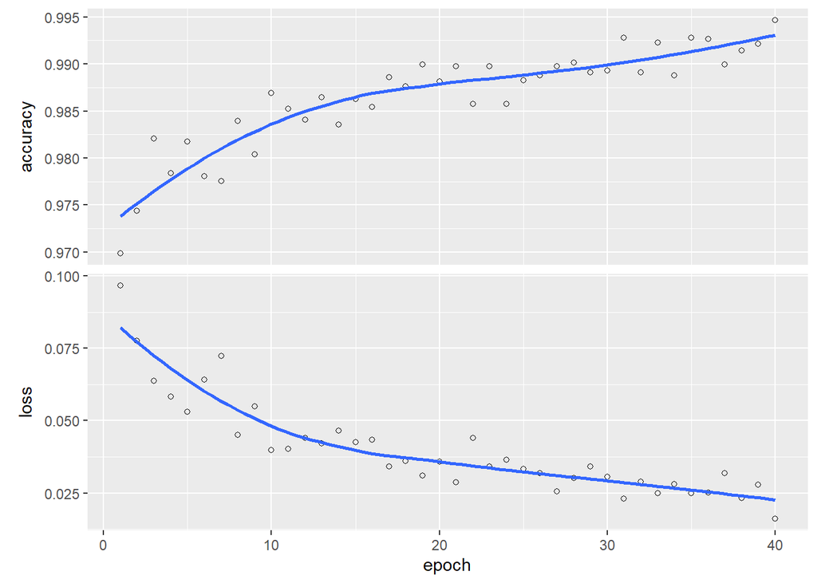

```r
plot(fit_model_finale)
```

```r
# uso il nuovo modello allenato su training e validation per la previsione sul test #

results <- model_drop_3 %>% predict(test_ds)
```

```
## 33/33 - 3s - 83ms/step
```

```r
pred_classes_f <- apply(results, 1, which.max)

# estraggo classi vere

iter_test <- as_iterator(test_ds)
true_classes_test <- c()

repeat {
  batch <- tryCatch(iter_next(iter_test), error = function(e) NULL)
  if (is.null(batch)) break

  y_batch <- as.array(batch[[2]])
  y_batch_classes <- apply(y_batch, 1, which.max)  # converte one-hot in numeri di classe
  true_classes_test <- c(true_classes_test, y_batch_classes)
}


# converti in nomi di classe
pred_class_names_test <- class_names[pred_classes_f]
true_class_names_test <- class_names[true_classes_test]

# matrice di confusione
confusion_matrix_test <- table(Predicted = pred_class_names_test, True = true_class_names_test)

metriche_finali<-metrics(confusion_matrix_test)
metriche_finali$per_class
```

```
##        Class  TP FP FN  TN Precision Recall Specificity    F1
## 1     glioma 241  3  3 808     0.988  0.988       0.996 0.988
## 2    healthy 298  2  2 753     0.993  0.993       0.997 0.993
## 3 meningioma 242  5  4 804     0.980  0.984       0.994 0.982
## 4  pituitary 264  0  1 790     1.000  0.996       1.000 0.998
```

```r
metriche_finali$accuracy  ###95%
```

```
## [1] 0.991
```

```r
print(metriche_finali)
```

```
## $per_class
##        Class  TP FP FN  TN Precision Recall Specificity    F1
## 1     glioma 241  3  3 808     0.988  0.988       0.996 0.988
## 2    healthy 298  2  2 753     0.993  0.993       0.997 0.993
## 3 meningioma 242  5  4 804     0.980  0.984       0.994 0.982
## 4  pituitary 264  0  1 790     1.000  0.996       1.000 0.998
##
## $accuracy
## [1] 0.991
```

# 5. Conclusioni

### Architettura del Modello CNN (con Data Augmentation e Dropout)

Il modello **CNN** `model_drop_3` utilizzato per fare previsioni sul test set si rileva ottimo.

Per chiarezza espositiva si ripresenta la seguente architettura nel passo seguente:

Tuttavia, tenendo conto dei seguenti fattori:

- I risultati già raggiunti, sono molto soddisfacenti.
- La **dimensione del test set**, pari a 1055 osservazioni.
- Il fatto che il problema presenti solo **quattro classi**.
- Il **sforzo computazionale significativo** richiesto per addestrare ogni modello (alcune ore).

Si decide di non proseguire con l’implementazione della **conformal prediction**.

In modo più approfondito, il principale limite che guida questa scelta è dettata dalla **dimensione campionaria** del test set: per applicare la conformal prediction sarebbe necessario sacrificare una parte del test set per costituire un *calibration set*, il che ridurrebbe ulteriormente la quantità di dati disponibili per la valutazione finale del modello.

Seppure questa procedura risulterebbe comunque corretta, sebbene la pratica comune preveda che la costruzione del *calibration set* avvenga a partire dal training set, la **la dimensione campionaria** del test set che s otterrebbe e la **complessità computazionale** necessaria, non giustificano il guadagno in termini di interpretabilità dei risultati che si otterrebbe.

Pertanto, si conclude che l’accuratezza raggiunta, insieme alle ottime metriche di classificazione, sia sufficiente per il contesto attuale.